# Workshop: Multiple Imputation in R

## 6 Step 5: Perform Multiple Imputation

Use `mice` with predictive mean matching (pmm) for continuous vars, logistic for binary (though disease has no missings).

```r
# Initialize imputation (quick check)
ini <- mice(data_missing, maxit = 0)  # Gets default methods

# Run MI: 5 imputations, 10 iterations (default meth='pmm' for continuous)
imp <- mice(data_missing, m = 5, maxit = 10, method = 'pmm', seed = 123)
# View imputation summary
summary(imp)
```

```
Class: mids
Number of multiple imputations:  5
Imputation methods:
        age      gender         sbp cholesterol     disease
         ""          ""       "pmm"       "pmm"          ""
PredictorMatrix:
            age gender sbp cholesterol disease
age           0      1   1           1       1
gender        1      0   1           1       1
sbp           1      1   0           1       1
cholesterol   1      1   1           0       1
disease       1      1   1           1       0
```

```r
imp$imp$sbp  # View imputed values for sbp in each of 5 datasets
```

```
           1        2        3        4        5
11  150.6400 150.6400 150.7182 139.1597 147.0346
18  143.4432 155.3836 143.4040 134.9264 139.8879
20  134.9391 152.0965 146.6613 147.9637 143.9789
22  137.7108 158.9177 143.8104 137.7108 158.0949
29  121.8521 155.3836 144.8238 129.7153 158.4138
35  152.1910 144.4197 151.0227 163.3833 156.4160
54  160.9698 151.8679 158.9832 158.9832 154.4565
73  160.9698 156.8871 136.0985 165.0391 159.6973
89  156.5339 140.7124 146.1055 143.8104 142.7841
90  158.1806 147.0346 148.5807 158.1806 142.7841
114 145.3743 165.0391 138.7003 158.4138 148.6589
142 158.4138 157.0377 133.6083 131.6002 142.5116
162 143.7383 141.0368 122.2011 143.8843 144.8238
169 157.3079 142.5116 145.5011 148.2066 146.4325
171 131.2147 146.0993 149.0003 131.6002 144.4197
175 142.0794 131.6403 149.7078 150.1539 143.8104
179 134.5979 151.0139 148.8287 134.5979 136.0985
188 131.6403 146.1055 144.8940 140.1755 152.1280
190 153.9325 131.9878 132.8312 129.7153 134.3266
197 162.3120 128.2694 135.8200 134.5979 164.5828
```

- **What this does**: `mice()` imputes via chained equations (iterates over variables). m=5 datasets; pmm uses observed values close to predicted.
- **Expected output**:
  - summary(imp): Shows imputation chain, methods (pmm for sbp/cholesterol).
  - imp$imp$sbp: A 20x5 matrix (rows=missing cases, columns=imputations) with plausible values ~140-150 range.

Check convergence (trace plots should stabilize):

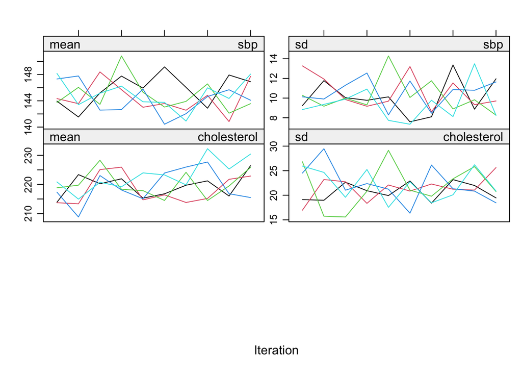

```r
plot(imp)  # Trace plots for mean/SD of imputations
```

- **Expected**: Lines for each imputation chain flatten after iterations (good convergence).

## 7 Step 6: Analyze the Imputed Datasets

Fit a logistic regression on each imputed dataset: disease ~ age + gender + sbp + cholesterol.

```r
# Fit model on each imputed dataset
fit <- with(imp,
            glm(disease ~ age + gender + sbp + cholesterol,
                     family = binomial))

# View one example fit
summary(fit$analyses[[1]])
```

```
Call:
glm(formula = disease ~ age + gender + sbp + cholesterol, family = binomial)

Coefficients:
             Estimate Std. Error z value Pr(>|z|)
(Intercept) -5.768184   2.590792  -2.226  0.02599 *
age          0.049413   0.017541   2.817  0.00485 **
gender      -0.157686   0.310748  -0.507  0.61185
sbp         -0.001305   0.014307  -0.091  0.92732
cholesterol  0.015410   0.007755   1.987  0.04690 *
---
Signif. codes:  0 '***' 0.001 '**' 0.01 '*' 0.05 '.' 0.1 ' ' 1

(Dispersion parameter for binomial family taken to be 1)

    Null deviance: 275.64  on 199  degrees of freedom
Residual deviance: 260.73  on 195  degrees of freedom
AIC: 270.73

Number of Fisher Scoring iterations: 4
```

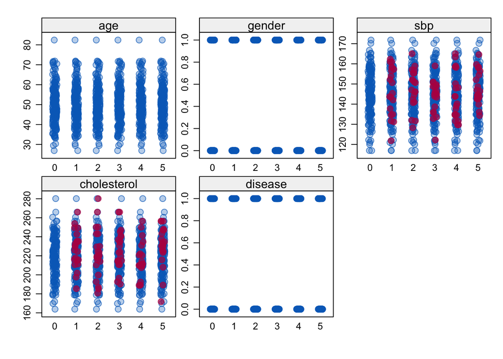

```r
#View graphically the imputed values for the different values
stripplot(imp , pch = c(21, 20), cex = c(1, 1.5))
```

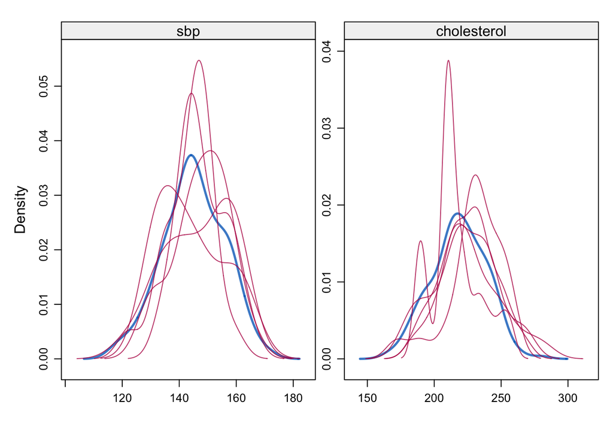

```r
#The distribution of the variables in the imputed datasets
densityplot(imp , layout = c(2, 1))
```

- **What this does**: `with()` applies glm to each of the 5 imputed datasets.
- **Expected output**: List of 5 glm summaries. Each like a standard glm output, e.g., coefficients for age positive/significant, ORs >1 for risk factors. Variances differ slightly across imputations.

#### 7.0.1 Step 7: Pool Results and Interpret

Combine estimates using Rubin’s rules for valid SEs/confidence intervals.

```r
# Pool the results
pooled <- pool(fit)

# Summary of pooled estimates
summary(pooled)
```

```
         term     estimate   std.error   statistic        df     p.value
1 (Intercept) -5.789083839 2.719388828 -2.12881798 147.84159 0.034926562
2         age  0.047438144 0.017742251  2.67373884 179.49433 0.008193198
3      gender -0.136711853 0.313121284 -0.43660990 182.58189 0.662910159
4         sbp  0.000838251 0.015576747  0.05381425  94.31419 0.957196984
5 cholesterol  0.014501995 0.008195971  1.76940531 105.08021 0.079727262
```

```r
# Pooled coefficients and confidence intervals
poolsummary <- summary(pooled, conf.int = TRUE)
poolsummary
```

```
         term     estimate   std.error   statistic        df     p.value
1 (Intercept) -5.789083839 2.719388828 -2.12881798 147.84159 0.034926562
2         age  0.047438144 0.017742251  2.67373884 179.49433 0.008193198
3      gender -0.136711853 0.313121284 -0.43660990 182.58189 0.662910159
4         sbp  0.000838251 0.015576747  0.05381425  94.31419 0.957196984
5 cholesterol  0.014501995 0.008195971  1.76940531 105.08021 0.079727262
          2.5 %      97.5 %      conf.low   conf.high
1 -11.162976733 -0.41519095 -11.162976733 -0.41519095
2   0.012427921  0.08244837   0.012427921  0.08244837
3  -0.754513294  0.48108959  -0.754513294  0.48108959
4  -0.030088403  0.03176490  -0.030088403  0.03176490
5  -0.001748957  0.03075295  -0.001748957  0.03075295
```

```r
#The tbl_regression does the pooling automatically!
tbl_regression(fit, exponentiate = T)
```

| **Characteristic** | **OR** | **95% CI** | **p-value** |
| --- | --- | --- | --- |
| age | 1.05 | 1.01, 1.09 | 0.008 |
| gender | 0.87 | 0.47, 1.62 | 0.7 |
| sbp | 1.00 | 0.97, 1.03 | >0.9 |
| cholesterol | 1.01 | 1.00, 1.03 | 0.080 |

Abbreviations: CI = Confidence Interval, OR = Odds Ratio

- **What this does**: `pool()` averages coefficients, adjusts SEs for imputation uncertainty.
- **Expected output** (example pooled summary; actual values depend on data):

## 8 Step 8: Compare to Complete-Case Analysis (For Illustration)

To see MI’s benefits, run on complete cases (biased under MAR).

```r
# Complete-case logistic regression
fit_cc <- glm(disease ~ age + gender + sbp + cholesterol,
              family = binomial,
              data = data_missing[complete.cases(data_missing), ])
tbl_regression(fit_cc, exponentiate = T)
```

| **Characteristic** | **OR** | **95% CI** | **p-value** |
| --- | --- | --- | --- |
| age | 1.04 | 1.00, 1.08 | 0.058 |
| gender | 1.04 | 0.53, 2.04 | >0.9 |
| sbp | 1.00 | 0.97, 1.03 | >0.9 |
| cholesterol | 1.01 | 1.00, 1.03 | 0.11 |

Abbreviations: CI = Confidence Interval, OR = Odds Ratio

```r
# Merge the CC and MICE tables into one object
tbl_cc <- tbl_regression(fit_cc, exponentiate = T)
tbl_mi <- tbl_regression(fit, exponentiate = T)

tbl_merged <- tbl_merge(
  # A list of the tables to merge
  tbls = list(tbl_cc, tbl_mi),

  # The labels that will appear above each column
  tab_spanner = c("**Complete Case**", "**Multiple Imputation**")
)

# Display the final, merged table
tbl_merged
```

| **Characteristic** | **Complete Case** **OR** | **Complete Case** **95% CI** | **Complete Case** **p-value** | **Multiple Imputation** **OR** | **Multiple Imputation** **95% CI** | **Multiple Imputation** **p-value** |
| --- | --- | --- | --- | --- | --- | --- |
| age | 1.04 | 1.00, 1.08 | 0.058 | 1.05 | 1.01, 1.09 | 0.008 |
| gender | 1.04 | 0.53, 2.04 | >0.9 | 0.87 | 0.47, 1.62 | 0.7 |
| sbp | 1.00 | 0.97, 1.03 | >0.9 | 1.00 | 0.97, 1.03 | >0.9 |
| cholesterol | 1.01 | 1.00, 1.03 | 0.11 | 1.01 | 1.00, 1.03 | 0.080 |

Abbreviations: CI = Confidence Interval, OR = Odds Ratio

## 9 Workshop Exercises

1. Increase missing % to 30%—how does FMI change?
2. Try other methods (e.g., method=‘norm’ for normal imputation).
3. Impute with interactions (e.g., predictorMatrix in mice).
4. Use `mitml` or `Amelia` for alternatives.

This covers a full MI workflow! If you have questions or want to adapt for real data (e.g., NHANES), let me know. Remember, MI assumes MAR; diagnostics are key.